# S2_Informe

# Índice

## Introducción

- Relevancia del tema escogido
- Objetivos
- Contexto

## Datos

-Proceso de recolección de datos

-Población, muestra y muestreo

-Variables

-Limpieza de base de datos

## Análisis descriptivo

### Introducción:

TEMA: La realidad académica en las universidades Universidad de Ingeniería y Tecnología (UTEC) y Universidad Mayor de San Marcos (UNMSM), durante el período del mes de Abril del 2023.

#### Relevancia del tema:

Un tema medular en toda sociedad orientada en su desarrollo como civilización, es la educación; ya que la educación como derecho fundamental del ser humano toma un rol determinante en las sociedades. El análisis de las realidades de estas dos universidades nos brinda datos de relevancia ya que nos proporciona información que ayudarán a las instituciones o entes en materia educativa a tomar desiciones informadas y gestionar acciones estructurales. El tener un análisis estadístico de un panorama integral proporciona información para el desarrollo institucional y mejora continua de ambas instituciones. La identificación de las áreas donde cada universidad destaca y las oportunidades de mejora, permitirá implementar estrategias efectivas para optimizar la calidad en la educación superior, por ello la información optenida puede ser utilizada por como puntos de referencia, ya que permitirán optimizar las prácticas y estándares teniendo en consideración una educación integral, inclusiva y con una estructuración requerida. De este modo, este trabajo tratará sobre la realidad académica de las universidades UTEC (Universidad de Ingeniería y Tecnología) (privada) y UNMSM (Universidad Nacional Mayor de San Marcos) (pública), durante el mes de Abril del 2023.

#### Objetivos:

##### Objetivo general

Analizar las variables que influyen en la realidad académica de los estudiantes de las universidades de Universidad de Ingeniería y Tecnología (UTEC) y Universidad Nacional Mayor de San Marcos (UNMSM), durante el período 2023.

##### Objetivos específicos

-Determinar si existe una diferencia en la realidad académica entre una universidad pública(UNMSM) y privada(UTEC).

-Evaluar los recursos que se han destinado para fomentar la inclusión sin distinción de raza, género en los estudiantes en las universidades y cómo han sido utilizados.

-Analizar los factores que pueden estar afectando el acceso y permanencia de los estudiantes en la educación superior.

-Determinar las diferencias entre estudiantes de la universidad pública(UNMS) y privada(utec).

#### Contexto:

El presente informe de estadística tiene como objetivo analizar las variables que influyen en la realidad académica de los estudiantes de dos importantes universidades del Perú: la Universidad de Ingeniería y Tecnología (UTEC) y la Universidad Nacional Mayor de San Marcos (UNMSM). El período de estudio abarca el año 2023 y se enfoca en comprender cómo diferentes factores pueden afectar el rendimiento académico de los estudiantes en estas instituciones.El análisis de la realidad académica de los estudiantes universitarios es de suma importancia, ya que proporciona información clave para el desarrollo de estrategias.

### Datos:

#### Proceso de recolección de datos

Se obtendrán los datos a través de la técnica de muestreo por encuestas. Para ello, se realizó una serie de preguntas, cuyas respuestas permiten ser clasificadas en varios tipos de variables para un mejor análisis del problema. Además, cada integrante del grupo se asegurará de la veracidad y exactitud de sus encuestados. En un principio planteamos tomar una base de datos realizada por una institución fiable, sin embargo para nuestro tipo de análisis no hayamos la suficiente cantidad de variables es por ello que decidimos realizar una encuesta y de esta manera tener una riqueza en nuestra cantidad de variables. Escogimos como primer punto de encuesta a nuestra universidad por contrar con los requerimientos que nos planteamos como grupo y la siguiente universidad propuesta fue la Universidad Nacional Mayor de San Marcos, que cuenta con una gran población estudiantil con una variedad de carreras y ser una universidad pública que representa una población estudiantil a nivel nacional. Como equipo nos distribuimos encuestados entre ambas universidades, logrando la cantidad requerida para nuestro análisis.

### Variables:

##### Cualitativa:

Nominal:

- Área universitaria (Carreras ): Con restricción de áreas de carreras que ofrecen las universidades UTEC y UNMSM.
- Orientación sexual (Orientación): Con restricción de que sea heteroxual, homosexual, bisexual y otros.
- Nombre de universidad (Universidad): Con restricción de las universidades (UTEC y UNMSM).
- Discriminación dentro de la universidad (Discriminación): Con restricción de responder sí o no.
- Egresó del colegio (Colegio): Con restricción de que sea público o privado.
- Soporte de material académico (Material académico): Con restricción que sean artefactos tecnológicos utilizados únicamente para el uso universitario.
- Acceso a laboratorios (Laboratorios): Con restricción de responder si o no.
- Asociaciones estudiantiles (Oportunidad de liderazgo): Con restricción de responder sí o no.
- Servicio de salud física y mental (Servicio de salud ): Con restricción de responder sí o no.
- Soporte técnico brindado por la universidad (Soporte técnico): Con restricción de responder sí o no.
- Género: Con restricción de que sea femenino, masculino, otros.

Ordinal:

- Nivel de estrés: Con restricción de que solo esté dentro de nada, poca,regular y mucha.
- Situación económica (Nivel socioeconómico): Con restricción de que solo esté dentro de clase baja, clase media o clase alta.
- Carga académica: Con restricción de que solo esté dentro de nada, poca, regular y mucha.
- Nivel académico de los padres( Grado de padres): Con restricción de que sea primaria, secundaria, universidad y posgrado.
- Región de procedencia (Región): Con restricción de que sea costa, sierra, selva.

##### Cuantitativa:

Discreta:

- Edad: Con restricción de número de años de 17 años en adelante.
- Puntuación de satisfacción con la universidad (Satisfacción): Con restricción del 1 al 5 (1 poca satisfacción y 5 alta satisfacción).
- Nivel de compromiso: Con restricción del 1 al 5 (uno poco compromiso y 5 alto compromiso).
- Calidad de enseñanza de los profesores: Con restricción del 1 al 5 (uno poco y 5 alta).

Continua:

### Limpieza de datos

Para la limpieza de datos, al ya ser una base de datos creado por nosotros mismos, no tuvimos que hacer muchas correcciones. Cambiamos el nombre de todas las variables ya que estas eran demasiadas largas. Habían dos columnas, las cuales no nos brindaban ningún dato, es decir, eran NA’s por lo tanto procedimos a eliminarlas. También al momento de realizar la revisión de la base de datos, nos percatamos que habían unos datos atípicos que ya sobrepasaban la línea de exageración, también se realizó la eliminación de esos datos. Finalmente nos dimos cuenta que las respuestas de la variable Universidades contaba con un nombre muy largo, por consiguiente, como solo eran dos posibles respuestas, cambiamos el nombre largo por un nombre mucho más corto y digerible.

```r
library(readr)
library(dplyr)
```

```r
library(ggplot2)
```

```r
base_datos<-read_csv("Base_de_Datos_Calidad.csv")
borrar <- c("Marca temporal","Dirección de correo electrónico")
B2 <- base_datos[ , !(names(base_datos) %in% borrar)]
```

```r
B3=rename(B2, Universidad='¿Cuál es tu universidad?', Genero ='¿Cuál es tu género?', Orientacion='Orientación sexual',Colegio = 'Tipo de colegio del que egresaste',Carrera='Seleccione su área de carrera universitaria',Apoyo='¿Cuentas con el apoyo económico de tus padres?',Grado='¿Cuál es el grado de escolarización\n de tus padres?', Oportunidad_de_liderazgo='¿Has tenido oportunidad de liderazgo en asociaciones estudiantiles dentro de tu universidad?',Equidad='¿Hay equidad en las representaciones universitarias de hombres y mujeres?', Discriminacion='¿Has experimentado algún tipo de discriminación a lo largo de tu carrera universitaria?', Tipo_de_discriminacion='Si en caso sufriste discriminación. ¿Qué tipo de discriminación fue?', Material_academico='¿Con qué tipo de material acedémico cuentas?', Laboratorios='¿Tú facultad cuenta con laboratorios idóneos para la carrera que estudias?', Servicio_salud_fisica_y_mental= '¿Tu universidad cuenta con servicios de apoyo de salud física y mental?', Nivel_de_estres='¿Cuál es el nivel de estrés que sientes en los estudios?', Nivel_socioeconómico='¿Cuál es tu nivel socioeconómico? A significa clase alta y E baja', Nivel_de_compromiso='Tu nivel de compromiso con tu universidad', Carga_academica='¿Cúal es la carga académica que tienes?', Region= '¿Cúal es tu región de procedencia?', Promedio='¿Cuál es tu promedio ponderado?', Tiempo = '¿Cuánto tiempo te toma a ir a tu universidad?(Responder en minutos)', Tiempo_de_matricula='¿Cuánto tiempo demora tu proceso de matricula?   Responder en horas, tomar en cuenta que 30 minutos es 0.5 horas. Los decimales se escriben con PUNTO', Mensualidad='Aproximadamente ¿cuál es tu mensualidad o el gasto mensual destinado a la universidad? Coloque número', Satisfaccion='Cual tu nivel de satifacción con tu universidad', Satisfaccion_Profesores='Cuál consideras que es el nivel de satisfacción con tus profesores', Preparacion='¿Cuál fue tu tiempo de preparación preuniversitaria? Responder en años, tomar en cuenta que un año es 1 y medio año 0.5. Los decimales se escriben con PUNTO', Soporte_tecnico='Tu universidad cuenta con soporte técnico, es decir brinda computadoras, acceso a internet, etc.', Beca='¿Cuentas con alguna beca o crédito estudiantil?')
```

```r
B3<-filter(B3, Edad <=35, Promedio<=20, Mensualidad>=150,Tiempo_de_matricula<=5, Preparacion<=10)
```

```r
B3$Edad <- as.integer(B3$Edad)
```

```r
summary(B3)
```

```
##  Universidad           Genero               Edad       Orientacion
##  Length:198         Length:198         Min.   :17.00   Length:198
##  Class :character   Class :character   1st Qu.:19.00   Class :character
##  Mode  :character   Mode  :character   Median :20.00   Mode  :character
##                                        Mean   :20.34
##                                        3rd Qu.:21.75
##                                        Max.   :28.00
##    Colegio            Carrera             Apoyo               Beca
##  Length:198         Length:198         Length:198         Length:198
##  Class :character   Class :character   Class :character   Class :character
##  Mode  :character   Mode  :character   Mode  :character   Mode  :character
##
##
##
##     Grado           Oportunidad_de_liderazgo   Equidad
##  Length:198         Length:198               Length:198
##  Class :character   Class :character         Class :character
##  Mode  :character   Mode  :character         Mode  :character
##
##
##
##  Discriminacion     Tipo_de_discriminacion Material_academico
##  Length:198         Length:198             Length:198
##  Class :character   Class :character       Class :character
##  Mode  :character   Mode  :character       Mode  :character
##
##
##
##  Laboratorios       Servicio_salud_fisica_y_mental Nivel_de_estres
##  Length:198         Length:198                     Length:198
##  Class :character   Class :character               Class :character
##  Mode  :character   Mode  :character               Mode  :character
##
##
##
##  Nivel_socioeconómico Nivel_de_compromiso Carga_academica       Region
##  Length:198           Min.   :1.000       Length:198         Length:198
##  Class :character     1st Qu.:4.000       Class :character   Class :character
##  Mode  :character     Median :4.000       Mode  :character   Mode  :character
##                       Mean   :4.106
##                       3rd Qu.:5.000
##                       Max.   :5.000
##     Promedio         Tiempo       Tiempo_de_matricula  Mensualidad
##  Min.   : 1.00   Min.   :  0.50   Length:198          Min.   :  150
##  1st Qu.:14.00   1st Qu.: 15.00   Class :character    1st Qu.:  370
##  Median :15.00   Median : 40.00   Mode  :character    Median :  900
##  Mean   :15.12   Mean   : 57.36                       Mean   : 1485
##  3rd Qu.:16.30   3rd Qu.: 90.00                       3rd Qu.: 2000
##  Max.   :20.00   Max.   :240.00                       Max.   :20000
##  Satisfaccion       Satisfaccion_Profesores Soporte_tecnico     Preparacion
##  Length:198         Length:198              Length:198         Min.   :0.010
##  Class :character   Class :character        Class :character   1st Qu.:0.500
##  Mode  :character   Mode  :character        Mode  :character   Median :1.000
##                                                                Mean   :1.213
##                                                                3rd Qu.:2.000
##                                                                Max.   :7.000
```

```r
head(B3)
```

| Universidad | Genero | Edad | Orientacion | Colegio | Carrera | Apoyo | Beca | Grado | Oportunidad_de_liderazgo | Equidad | Discriminacion | Tipo_de_discriminacion | Material_academico | Laboratorios | Servicio_salud_fisica_y_mental | Nivel_de_estres | Nivel_socioeconómico | Nivel_de_compromiso | Carga_academica | Region | Promedio | Tiempo | Tiempo_de_matricula | Mensualidad | Satisfaccion | Satisfaccion_Profesores | Soporte_tecnico | Preparacion |
| --- | --- | --- | --- | --- | --- | --- | --- | --- | --- | --- | --- | --- | --- | --- | --- | --- | --- | --- | --- | --- | --- | --- | --- | --- | --- | --- | --- | --- |
| Universidad de Ingeniería y tecnología (UTEC) | Femenino | 21 | Heterosexual | Privado | Ingenierías | Si | No | Estudios superiores completos | Sí | No | No | no sufri discriminación | Laptop, celular | Sí | Sí | Regular | D | 4 | regular | Costa | 14.18 | 120 | 0.5 | 2000 | 4 (buena) | 3 (regular) | Sí | 1.0 |
| Universidad de Ingeniería y tecnología (UTEC) | Masculino | 19 | Heterosexual | Privado | Ingenierías | Si | No | Estudios superiores completos | No | Si | No | no sufri discriminación | Laptop, celular | Sí | Sí | Mucha | C | 4 | mucha | Costa | 11.60 | 5 | 0.5 | 2500 | 3 (regular) | 3 (regular) | Sí | 0.1 |
| Universidad Nacional Mayor de San Marcos (UNMSM) | Femenino | 24 | Heterosexual | Privado | Ciencias de la Salud | Si | No | Técnico | Sí | Si | No | No sufrí discriminación | Laptop, Ipad, celular | No | Sí | Mucha | C | 2 | mucha | Costa | 16.10 | 120 | 0.5 | 200 | 3 (regular) | 3 (regular) | Sí | 5.0 |
| Universidad Nacional Mayor de San Marcos (UNMSM) | Masculino | 21 | Heterosexual | Público | Ciencias de la Salud | Si | Sí | Secundaria completa | No | Si | No | No sufrí discriminación | Laptop, celular | Sí | Sí | Regular | C | 4 | mucha | Costa | 15.00 | 120 | 120 | 200 | 4 (buena) | 4 (buena) | Sí | 2.0 |
| Universidad de Ingeniería y tecnología (UTEC) | Femenino | 24 | Heterosexual | Público | Ingenierías | Si | Sí | Universidad completa | Sí | No | No | Otros | Laptop, Ipad, celular, otros | Sí | Sí | Mucha | C | 5 | mucha | Sierra | 15.50 | 20 | 0.5 | 900 | 5 (muy buena) | 5 (muy buena) | Sí | 4.0 |
| Universidad Nacional Mayor de San Marcos (UNMSM) | Femenino | 23 | Heterosexual | Privado | Ciencias de la Salud | Si | No | Doctorado | Sí | Si | No | No sufrí discriminación | Laptop, tablet, celular, otros | Sí | Sí | Poca | C | 4 | regular | Costa | 16.30 | 10 | 0.05 | 200 | 3 (regular) | 2 (mala) | Sí | 4.0 |

Cambiamos el nombre de las variables universidad

```r
B3$Universidad <- recode(B3$Universidad, "Universidad de Ingeniería y tecnología (UTEC)"='UTEC', "Universidad Nacional Mayor de San Marcos (UNMSM)" ='UNMSM'     )
```

### Análisis descriptivo

#### OBJETIVO 1

1. laboratorios - universidad

```r
table(B3$Laboratorios)
```

```
##
##  No  Sí
##  40 158
```

```r
table(B3$Universidad)
```

```
##
## UNMSM  UTEC
##    75   123
```

```r
tabla_lab_uni = table(B3$Universidad,B3$Laboratorios)
tabla_lab_uni
```

```
##
##          No  Sí
##   UNMSM  32  43
##   UTEC    8 115
```

```r
round(prop.table(x=tabla_lab_uni)*100,2)
```

```
##
##            No    Sí
##   UNMSM 16.16 21.72
##   UTEC   4.04 58.08
```

```r
round(prop.table(x=tabla_lab_uni,margin=1)*100,2)
```

```
##
##            No    Sí
##   UNMSM 42.67 57.33
##   UTEC   6.50 93.50
```

```r
round(prop.table(x=tabla_lab_uni,margin=2)*100,2)
```

```
##
##            No    Sí
##   UNMSM 80.00 27.22
##   UTEC  20.00 72.78
```

```r
table(B3$Laboratorios,B3$Universidad) #tabla de 2 varaibles
```

```
##
##      UNMSM UTEC
##   No    32    8
##   Sí    43  115
```

```r
barplot( table(B3$Universidad))
```

[output not shown]

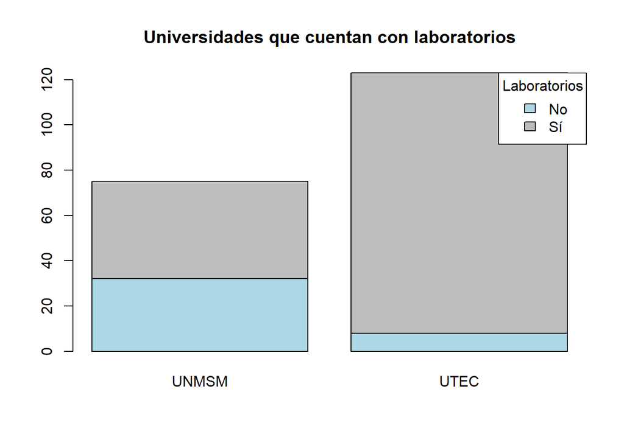

```r
barplot(table(B3$Laboratorios,B3$Universidad),
        main="Universidades que cuentan con laboratorios",
        col = c("lightblue", "grey"))
legend(x = "topright", legend = c("No", "Sí"), fill = c("lightblue", "grey"),  title = "Laboratorios")
```

Muestra de presencia o ausencia de laboratorios para cada universidad (UTEc y UNMSM)desde la perspectiva de los estudiantes, donde el eje X está representado por la variable “Universidad” y el eje y por la variable “Laboratorios” (donde la variable sus opciones son, si cuentan o no con laboratorios)

3. Soporte ténico - Universidades

```r
table(B3$Soporte_tecnico,B3$Universidad) #tabla de 2 varaibles
```

```
##
##      UNMSM UTEC
##   No    11    7
##   Sí    64  116
```

```r
barplot( table(B3$Universidad))
```

[output not shown]

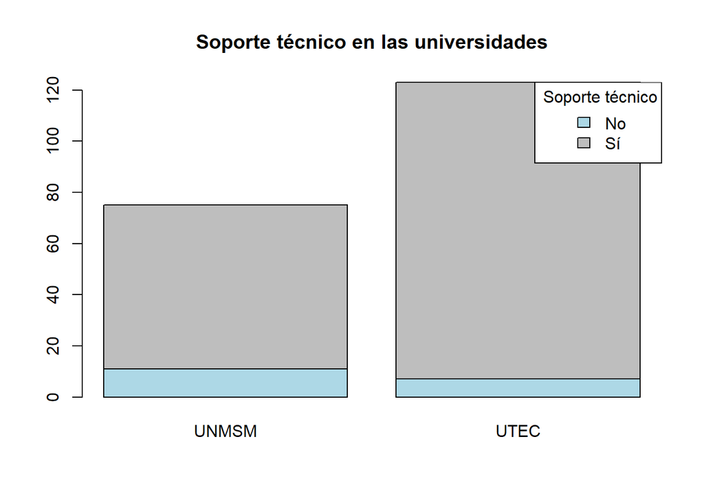

```r
barplot(table(B3$Soporte_tecnico,B3$Universidad),
        main = "Soporte técnico en las universidades",col = c("lightblue", "grey"))
legend(x = "topright", legend = c("No", "Sí"), fill = c("lightblue", "grey"),
       title = " Soporte técnico")
```

Muestra de presencia o ausencia de soporte ténico para cada universidad privada y pública (UTEc y UNMSM, respectivamente)desde la perspectiva de los estudiantes, donde el eje X está representado por la variable “Universidad” y el eje y por la variable “Soporte técnico” (donde la variable sus opciones son, si cuentan o no con soporte ténico).

Según la gráfica de barras, se puede observar que en ambas universidades los estudiantes afirmaron que sus universidades cuentan con soporte técnico, y que la diferencia entre ambas categorías de universidades es mínima. Esto sugiere que ambas universidades (tanto pública y privada) han hecho esfuerzos por proveer servicios de soporte técnico a sus estudiantes.

```r
table(B3$Servicio_salud_fisica_y_mental,B3$Universidad) #tabla de 2 variables
```

```
##
##      UNMSM UTEC
##   No    11    9
##   Sí    64  114
```

```r
barplot( table(B3$Universidad))
```

[output not shown]

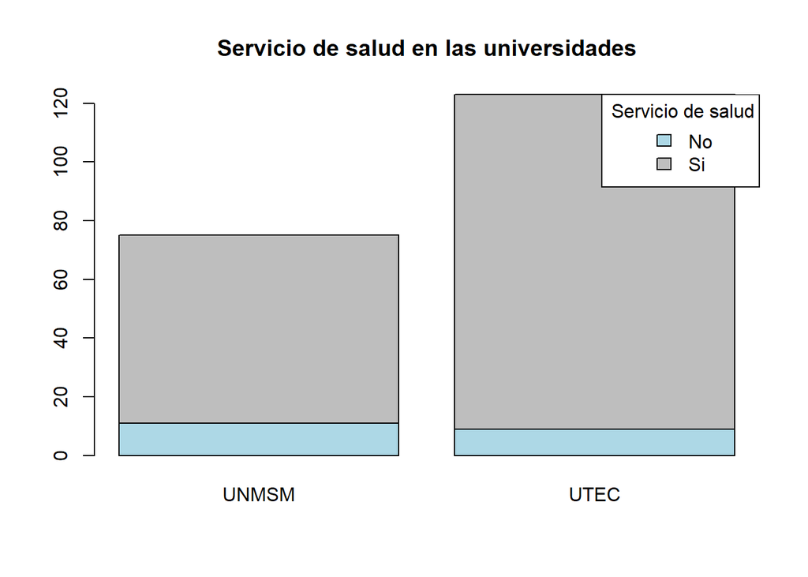

```r
barplot(table(B3$Servicio_salud_fisica_y_mental,B3$Universidad),
        main = "Servicio de salud en las universidades",col = c("lightblue", "grey"))
legend(x = "topright", legend = c("No", "Si"), fill = c("lightblue", "grey"),
       title = " Servicio de salud")
```

Muestra de presencia o ausencia de servicios de salud (tanto física como mental)desde la perspectiva de los estudiantes para cada universidad privada y pública (UTEc y UNMSM, respectivamente), donde el eje X está representado por la variable “Universidad” y el eje y por la variable “Serviciosalud_fisica_y_mental” (donde la variable sus opciones son, si cuentan o no con servicios de salud).

Según la gráfica de barras, se puede observar que en ambas universidades los estudiantes afirmaron que sus universidades cuentan con servicios de salud, y que la diferencia entre ambas categorías de universidades es mínima. Esto sugiere que ambas universidades (tanto pública y privada) han hecho esfuerzos por proveer servicios de salud a sus estudiantes.

4. Tiempo - Promedio

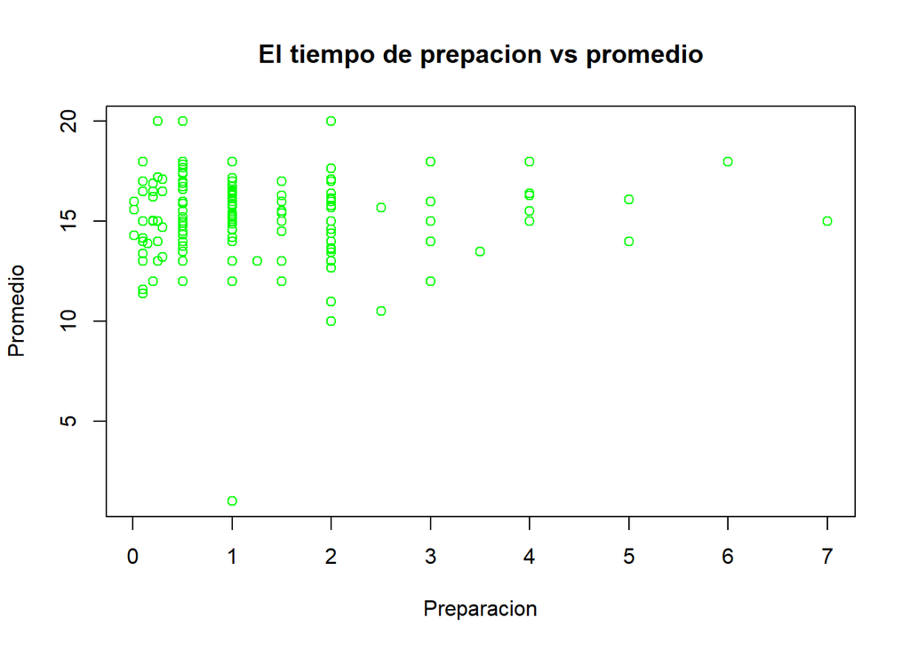

```r
plot(B3$Preparacion,B3$Promedio,
     main="El tiempo de prepacion vs promedio",
       xlab="Preparacion", ylab="Promedio",
       col="green")
abline(B3, col = "red")
```

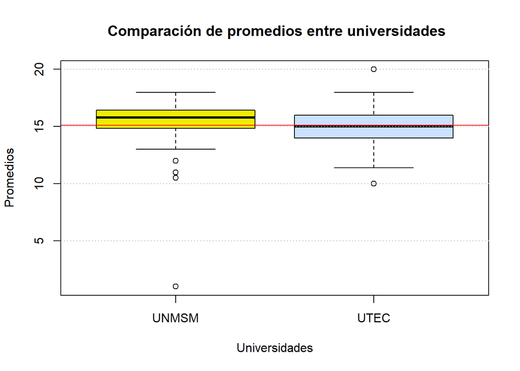

```r
tabla1 <- filter(B3, Universidad == "UNMSM")
tabla2 <-filter(B3, Universidad == "UTEC")
boxplot(tabla1$Promedio,tabla2$Promedio, names = c("UNMSM","UTEC"),main=" Comparación de promedios entre universidades",ylab = "Promedios", xlab = "Universidades", col = colorRampPalette(c('yellow2','lightsteelblue1'))(2))
grid(nx = NA, ny = NULL, lty = 3, col = "grey", lwd = 1)

abline(h=mean(B3$Promedio, na.rm = TRUE), col="red",lwd = 1) #MEDIA TOTAL
```

De acuerdo a los gráficos en los que comparamos los promedios de los alumnos pertenecientes a la Universidad de Ingenieria y Tecnologia y la Universidad Mayor de San Macos

El gráfico muestra el desempeño académico reflejado en las notas de los estudiantes entre ámbas universidades lo notamos un una pequeña diferencia

Podemos determinar que los alumnos de universidad Nacional Mayor de San Marcos tienen promedios más altos (se refleja mediante la mediana), y sus notas no son tan variables (se refleja mediante el largo de caja), por otro lado, sus valores minimos son más altos (se refleja en el vigote inferior) que los alumnos de la Universidad de Ingenieria y Tcenologia(UTEC)

La linea roja representa el promedio de las notas de ambas universidades, podemos darnos cuenta que el promedio es menor a la media de los alumnos de la UNMSM y casi similares a los de UTEC la razon es porque los datos atipicos existentes afectan al promedio.

#### OBJETIVO 2

BECA VS UNIVERSIDAD (TABLA CRUZADA)

```r
table(B3$Beca)
```

```
##
##  No  Sí
## 121  77
```

```r
table(B3$Universidad)
```

```
##
## UNMSM  UTEC
##    75   123
```

```r
tabla_beca = table(B3$Beca,B3$Universidad)
tabla_beca
```

```
##
##      UNMSM UTEC
##   No    66   55
##   Sí     9   68
```

```r
round(prop.table(x=tabla_beca)*100,2)
```

```
##
##      UNMSM  UTEC
##   No 33.33 27.78
##   Sí  4.55 34.34
```

```r
round(prop.table(x=tabla_beca,margin=1)*100,2)
```

```
##
##      UNMSM  UTEC
##   No 54.55 45.45
##   Sí 11.69 88.31
```

```r
round(prop.table(x=tabla_beca,margin=2)*100,2)
```

```
##
##      UNMSM  UTEC
##   No 88.00 44.72
##   Sí 12.00 55.28
```

Tipo de discrimanción vs universidad

```r
table(B3$Tipo_de_discriminacion)
```

```
##
##                                                        Estatus sociecónomico
##                                                                            7
##                                                                       Género
##                                                                            5
##                                                Género, Estatus sociecónomico
##                                                                            2
##                                                           Género, Raza/color
##                                                                            1
##                          Género, Raza/color, Estatus sociecónomico, Religión
##                                                                            2
## Género, Raza/color, Estatus sociecónomico, Religión, No sufrí discriminación
##                                                                            1
##                                                      no sufri discriminación
##                                                                            2
##                                                      No sufrí discriminación
##                                                                          149
##                                                                        Otros
##                                                                           19
##                                                                   Raza/color
##                                                                            7
##                                            Raza/color, Estatus sociecónomico
##                                                                            1
##                                     Raza/color, Estatus sociecónomico, Otros
##                                                                            1
##                                                                     Religión
##                                                                            1
```

```r
table(B3$Universidad)
```

```
##
## UNMSM  UTEC
##    75   123
```

```r
tabla_T_D = table(B3$Universidad,B3$Tipo_de_discriminacion)
tabla_T_D
```

```
##
##         Estatus sociecónomico Género Género, Estatus sociecónomico
##   UNMSM                     1      1                             1
##   UTEC                      6      4                             1
##
##         Género, Raza/color Género, Raza/color, Estatus sociecónomico, Religión
##   UNMSM                  0                                                   1
##   UTEC                   1                                                   1
##
##         Género, Raza/color, Estatus sociecónomico, Religión, No sufrí discriminación
##   UNMSM                                                                            0
##   UTEC                                                                             1
##
##         no sufri discriminación No sufrí discriminación Otros Raza/color
##   UNMSM                       0                      58     8          4
##   UTEC                        2                      91    11          3
##
##         Raza/color, Estatus sociecónomico
##   UNMSM                                 0
##   UTEC                                  1
##
##         Raza/color, Estatus sociecónomico, Otros Religión
##   UNMSM                                        0        1
##   UTEC                                         1        0
```

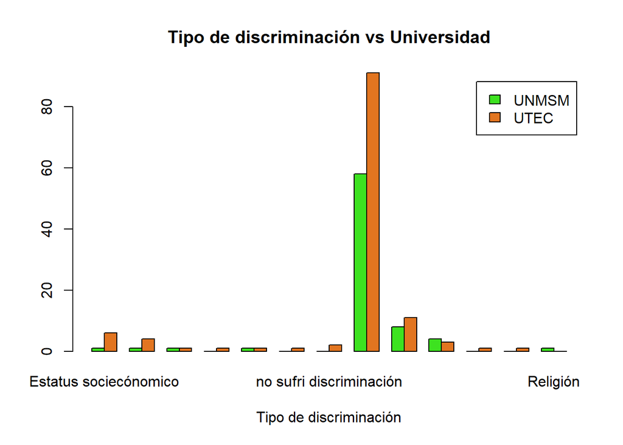

```r
# Simple Bar Plot
barplot(tabla_T_D, main="Tipo de discriminación vs Universidad",
  xlab="Tipo de discriminación", col=c("#3DE220", "#E27520"),
  legend = rownames(tabla_T_D), beside=TRUE)
```

#### OBJETIVO 3

[figure not shown]

```r
barplot(table(tabla1$Carga_academica),main="UNMSM - Nivel de Estrés en los estudios",xlab = "Nivel de estrés",col = colorRampPalette(c('seashell','seashell2','seashell3','seashell4'))(4))
```

[figure not shown]

```r
barplot(table(tabla2$Carga_academica),main="UTEC - Nivel de Estrés en los estudios",xlab = "Nivel de estrés",col = colorRampPalette(c('paleturquoise','paleturquoise2','paleturquoise3','paleturquoise4'))(4))
```

Preparación académica

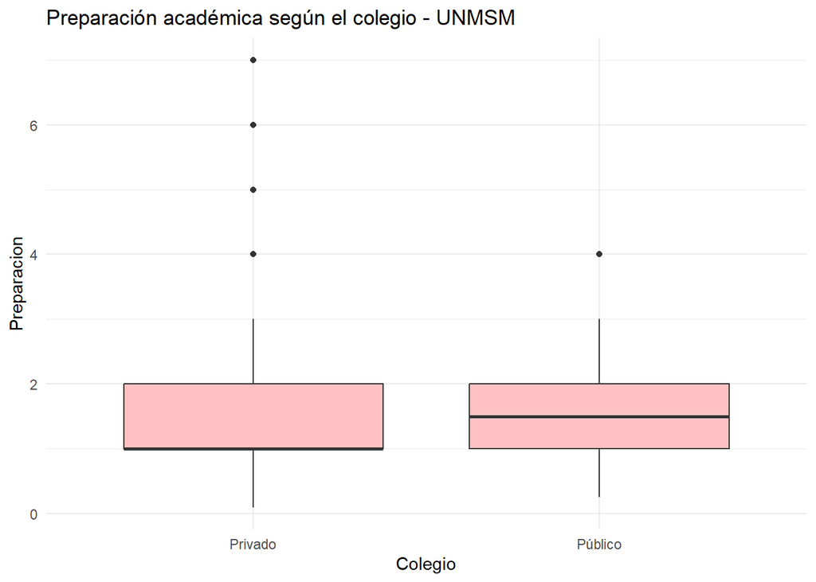

```r
ggplot(tabla1) +
 aes(x = Colegio, y = Preparacion) +
 geom_boxplot(fill = "rosybrown1") +
  labs(title = "Preparación académica según el colegio - UNMSM") +
 theme_minimal()
```

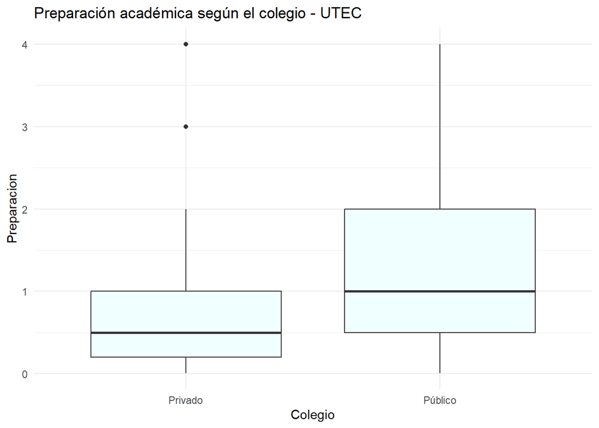

```r
ggplot(tabla2) +
 aes(x = Colegio, y = Preparacion) +
 geom_boxplot(fill = "azure") +
  labs(title = "Preparación académica según el colegio - UTEC") +
 theme_minimal()
```

La prepración para las universidades es un factor importante al momento de evaluar si se le dificulto el acceso a la universidad, ya sea por falta de estudios o sobre la calidad de estudios en tu colegio.

Universidad vs mensualidad

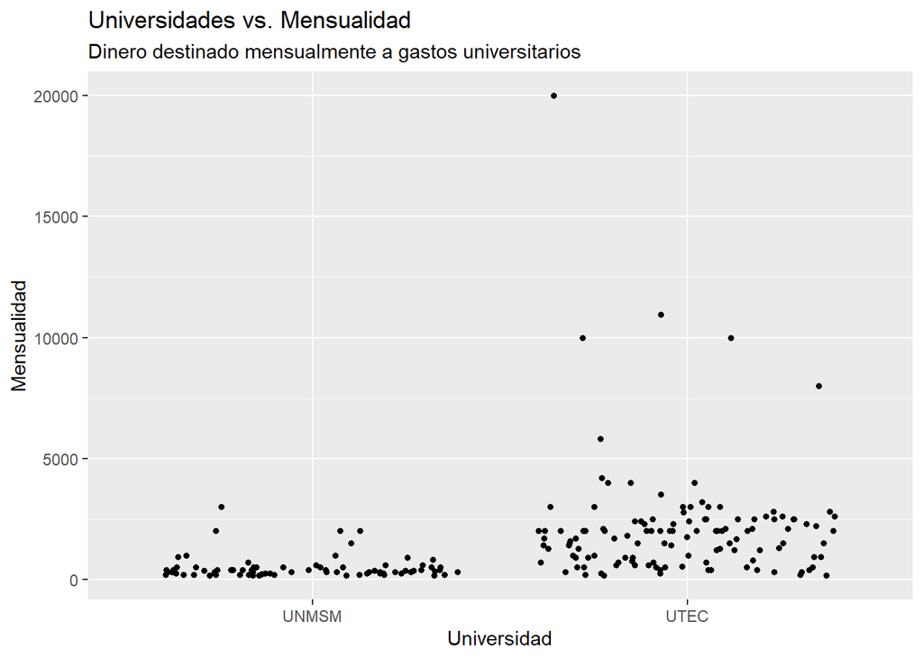

```r
ggplot(B3) +
 aes(x = Universidad, y = Mensualidad) +
 geom_jitter(size = 1.2) +
  labs(title = "Universidades vs. Mensualidad",
       subtitle = "Dinero destinado mensualmente a gastos universitarios")
```

```r
 theme_minimal()
```

[output not shown]

[output not shown]

Un factor importante también es tu mensualidad en la universidad, acá entran varios factores como los almuerzos, los desayunos o alguno que otro antojo; también vemos la pensión de la universidad. Este cuadro nos brinda información acerca la mensualidad y se notan alguno que otro dato atípico.

Grado vs mensualidad

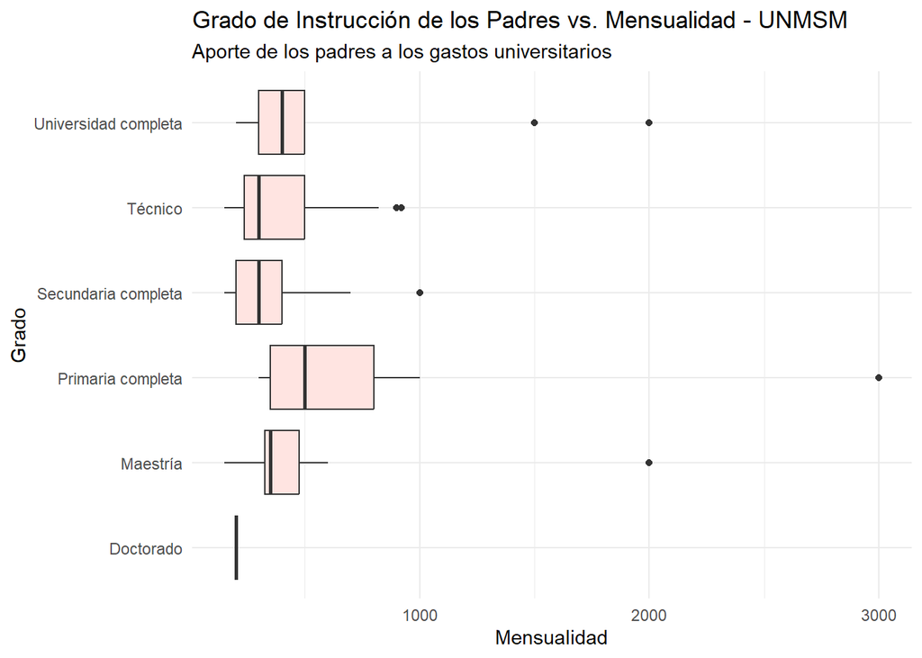

```r
ggplot(tabla1) +
 aes(x = Mensualidad, y = Grado) +
 geom_boxplot(fill = "mistyrose1") +
  labs(title = "Grado de Instrucción de los Padres vs. Mensualidad - UNMSM",
       subtitle = "Aporte de los padres a los gastos universitarios" ) +
 theme_minimal()
```

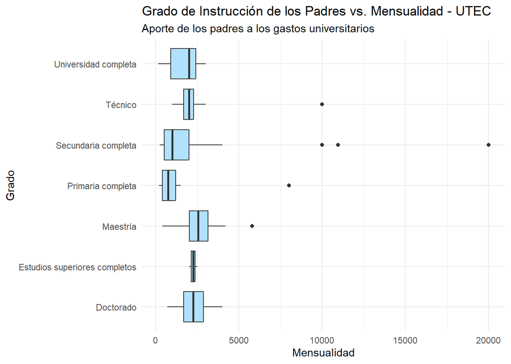

```r
ggplot(tabla2) +
 aes(x = Mensualidad, y = Grado) +
 geom_boxplot(fill = "#B0E2FF") +
  labs(title = "Grado de Instrucción de los Padres vs. Mensualidad - UTEC",
       subtitle = "Aporte de los padres a los gastos universitarios" ) +
 theme_minimal()
```

El grado de instrucción de los padres también es un dato a evaluar, saber esto nos puede dar indicios de los ingresos de su familia y evaluarlo sobre la mensualidad.

#### OBJETIVO 4

Región vs universidad

```r
#tabla 1
table(B3$Region)
```

```
##
##  Costa  Selva Sierra
##    148     10     40
```

```r
table(B3$Universidad)
```

```
##
## UNMSM  UTEC
##    75   123
```

```r
tabla_region = table(B3$Region,B3$Universidad)
tabla_region
```

```
##
##          UNMSM UTEC
##   Costa     62   86
##   Selva      4    6
##   Sierra     9   31
```

```r
#gráfico 1 y su análisis
tabla_region
```

```
##
##          UNMSM UTEC
##   Costa     62   86
##   Selva      4    6
##   Sierra     9   31
```

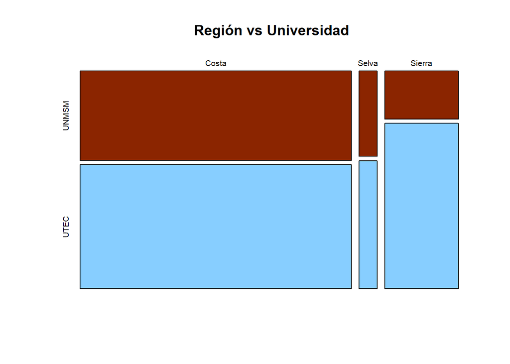

```r
mosaicplot(tabla_region,main=" Región vs Universidad",col=c("#8B2500","#87CEFF"))
```

Edad vs universidad

```r
#Tabla 2
table(B3$Edad)
```

```
##
## 17 18 19 20 21 22 23 24 25 26 27 28
## 15 34 38 36 25  9 16 13  4  3  2  3
```

```r
table(B3$Universidad)
```

```
##
## UNMSM  UTEC
##    75   123
```

```r
tabla_edad = table(B3$Edad,B3$Universidad)
tabla_edad
```

```
##
##      UNMSM UTEC
##   17     8    7
##   18     8   26
##   19    10   28
##   20     6   30
##   21    10   15
##   22     6    3
##   23     9    7
##   24     8    5
##   25     3    1
##   26     3    0
##   27     2    0
##   28     2    1
```

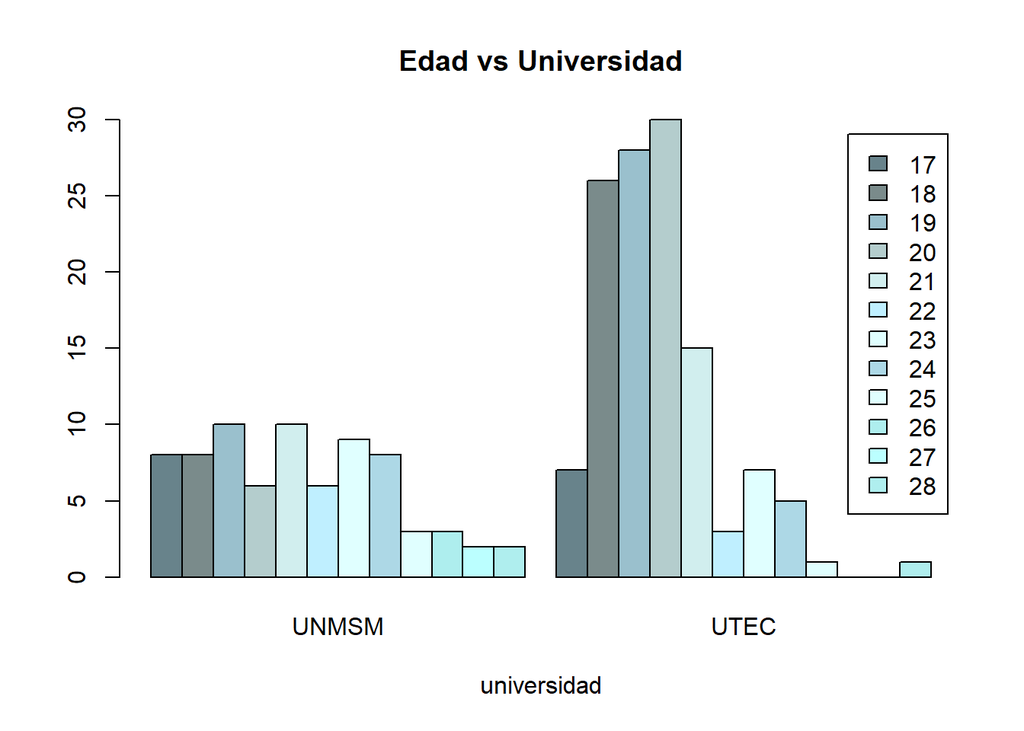

```r
#Grafico 2 y analisis
#  Bar Plot
barplot(tabla_edad, main="Edad vs Universidad",
  xlab="universidad", col=c("#68838B","#7A8B8B", "#9AC0CD", "#B4CDCD","#D1EEEE","#BFEFFF","#E0FFFF","#ADD8E6","#E0FFFF","#AEEEEE","#BBFFFF","#AFEEEE"),
  legend = rownames(tabla_edad), beside=TRUE)
```

Se utilizó el gráfico de barras para tener una mejor visión de las edades en cada universidad; podemos concluir que no podemos compararar las edades en forma genereal porque hay una gran diferencia, pero podemos inferir que la UTEC hay más estudiantes de edades 18, 19 y 20 mientras que en la san marcos los estudiantes tienen edad hasta los 24 de forma casi equitativa, esto se debe a que en la san marcos el in greso suele ser menos accesible que la UTEC ya sea por la modalidad de su admisión o los recursos de los estudiantes para ingresar a las casas de estudios”

Socioeconómico vs universidad

```r
#Factor antes del gráfico 3 y tabla 3
factor(B3$Nivel_socioeconómico, levels = c("E","D","C","B","A"),ordered = TRUE)
```

```
##   [1] D C C C C C C C C E D D C B C D C D D C D C D C D C C A B C A C E D B A D
##  [38] E D D E C E D A D D C E D D B B B C D D C E B C B A A B E C B E E E C E E
##  [75] C B D B C C E E E D D E E B E D E E C C C E C E D E C E E B D E C E B B D
## [112] D C B D A E C B E E E D D C D E C E B D E B E E E B C C C D D B E E C D C
## [149] C C B C D C C C B D C C D C B C B C C D C D C C C C B D C E D C C C E C C
## [186] B C C C C D C C C B C C E
## Levels: E < D < C < B < A
```

```r
#Tabla 3
table(B3$Nivel_socioeconómico)
```

```
##
##  A  B  C  D  E
##  7 29 75 44 43
```

```r
table(B3$Universidad)
```

```
##
## UNMSM  UTEC
##    75   123
```

```r
tabla_socio = table(B3$Nivel_socioeconómico,B3$Universidad)
tabla_socio
```

```
##
##     UNMSM UTEC
##   A     2    5
##   B     9   20
##   C    46   29
##   D    13   31
##   E     5   38
```

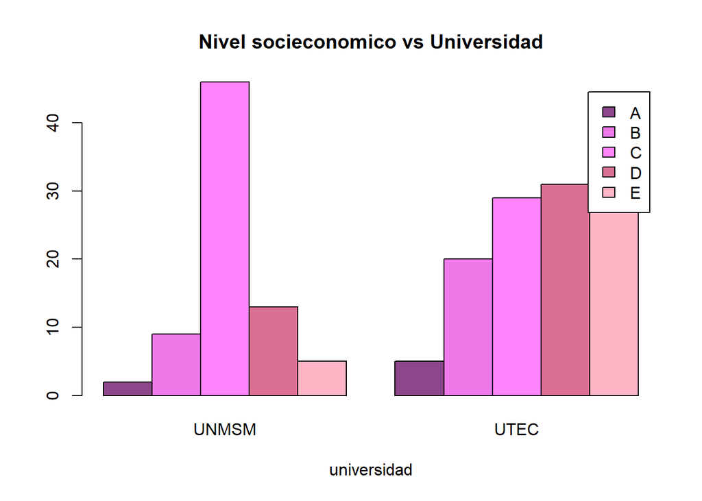

```r
#Gráfico 3
# Simple Bar Plot
barplot(tabla_socio, main="Nivel socieconomico vs Universidad",
  xlab="universidad", col=c("#8B4789","#EE7AE9", "orchid1", "#DB7093","#FFB5C5"),
  legend = rownames(tabla_socio), beside=TRUE)
```

Utilizamos el gráfico de barras para tener una mejor visión de las clases sociales de los estudiantes en las dos universidades estudiadas; a base del gráfico podemos mencionar que UNMSM hay más estudiantes de la clase C por lo mismo que es una universidad pública es más accesible estudiar por la situación economica, para el gráfico de la UTEC encontramos algo interesante, se observa que hay estudiantes de de distintas clases socieconomicas ¿A qué se debe esto? pues la UTEC cuenta con diversios programas de beca.